# AS4_DD2_MCS_Bivariate_Statistics_BHBA_3_18_20

Dopfer

3/18/2020

Set working directory

```
## [1] "C:/Users/sawalski/Desktop"
```

#Load libraries

```
##
## Call:
## glm(formula = BS.BHBA.1.2 ~ BS.Month_warm, family = binomial(link = logit),
##     data = hp9)
##
## Deviance Residuals:
##     Min       1Q   Median       3Q      Max
## -0.6966  -0.6966  -0.6145  -0.6145   1.8761
##
## Coefficients:
##                Estimate Std. Error z value Pr(>|z|)
## (Intercept)     -1.5710     0.1323 -11.874   <2e-16 ***
## BS.Month_warm1   0.2786     0.1911   1.457    0.145
## ---
## Signif. codes:  0 '***' 0.001 '**' 0.01 '*' 0.05 '.' 0.1 ' ' 1
##
## (Dispersion parameter for binomial family taken to be 1)
##
##     Null deviance: 694.46  on 711  degrees of freedom
## Residual deviance: 692.35  on 710  degrees of freedom
## AIC: 696.35
##
## Number of Fisher Scoring iterations: 4
```

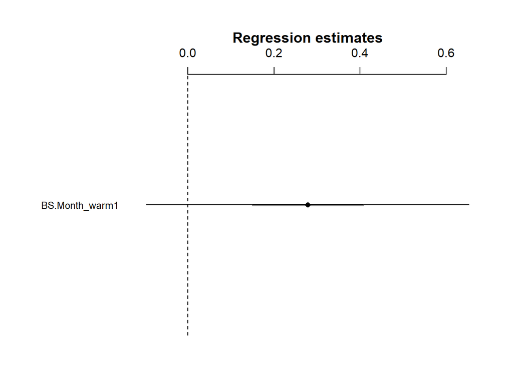

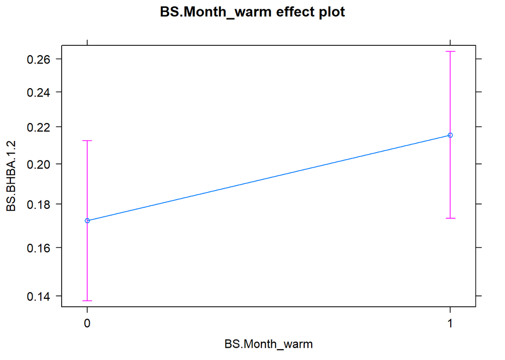

# AS uses these model to screen for bivariate effects, but the random effects models for the final model and backward step modeling approach

BS.BHBA.1.2 ~ BS.Month - BS.Month_warm compared to high or low BHBA levels (cutoff: >=1.2 is hi and <1.2 is low)

[output not shown]

```
##
##       0   1
##   0 332  69
##   1 244  67
```

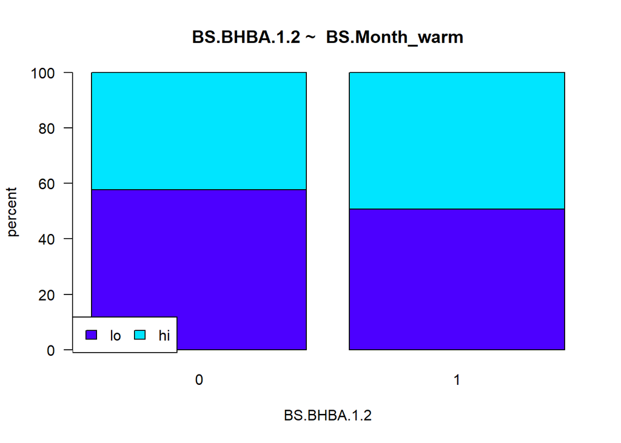

BS.BHBA.1.2 ~ MS.DIM - BS.Month_warm compared to high or low BHBA levels (cutoff: >=1.2 is hi and <1.2 is low)

```
##
## Call:
## glm(formula = BS.BHBA.1.2 ~ MS.DIM, family = binomial(link = logit),
##     data = hp9)
##
## Deviance Residuals:
##     Min       1Q   Median       3Q      Max
## -0.8146  -0.6862  -0.6188  -0.5633   2.0267
##
## Coefficients:
##             Estimate Std. Error z value Pr(>|z|)
## (Intercept) -0.83435    0.29501  -2.828  0.00468 **
## MS.DIM      -0.03279    0.01535  -2.136  0.03267 *
## ---
## Signif. codes:  0 '***' 0.001 '**' 0.01 '*' 0.05 '.' 0.1 ' ' 1
##
## (Dispersion parameter for binomial family taken to be 1)
##
##     Null deviance: 694.46  on 711  degrees of freedom
## Residual deviance: 689.85  on 710  degrees of freedom
## AIC: 693.85
##
## Number of Fisher Scoring iterations: 4
```

```
##                    OR     2.5 %    97.5 %
## (Intercept) 0.4341577 0.2417371 0.7697091
## MS.DIM      0.9677383 0.9388251 0.9971465
```

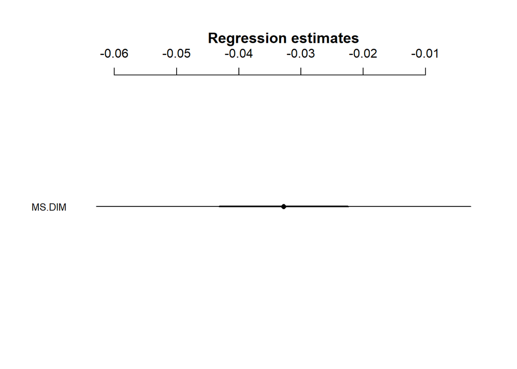

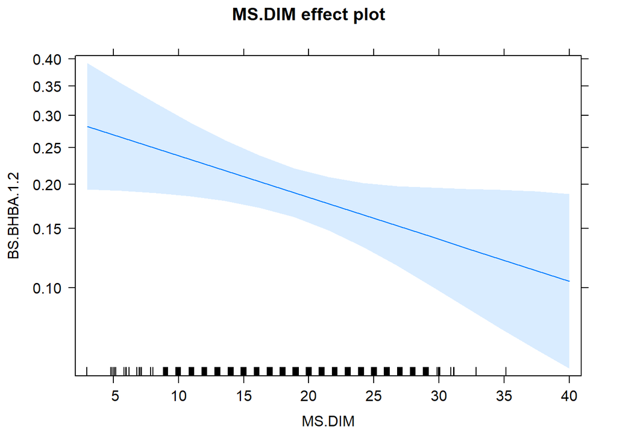

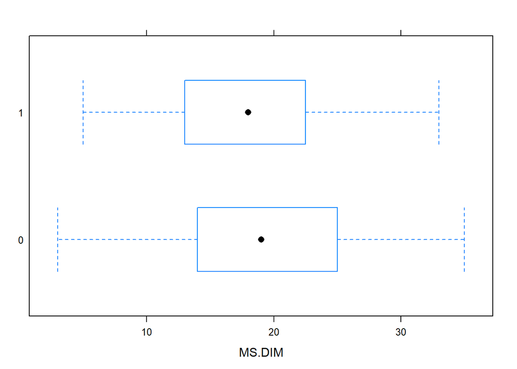

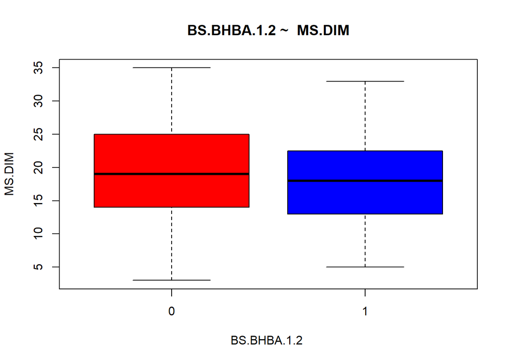

```
##
## Call:
## glm(formula = BS.BHBA.1.2 ~ CE.Fat.Level, family = binomial(link = logit),
##     data = hp9)
##
## Deviance Residuals:
##     Min       1Q   Median       3Q      Max
## -1.0432  -0.6712  -0.6014  -0.5479   2.0722
##
## Coefficients:
##              Estimate Std. Error z value Pr(>|z|)
## (Intercept)  -2.14410    0.25502  -8.408  < 2e-16 ***
## CE.Fat.Level  0.04044    0.01329   3.042  0.00235 **
## ---
## Signif. codes:  0 '***' 0.001 '**' 0.01 '*' 0.05 '.' 0.1 ' ' 1
##
## (Dispersion parameter for binomial family taken to be 1)
##
##     Null deviance: 675.70  on 694  degrees of freedom
## Residual deviance: 666.63  on 693  degrees of freedom
##   (17 observations deleted due to missingness)
## AIC: 670.63
##
## Number of Fisher Scoring iterations: 4
```

```
##                     OR      2.5 %    97.5 %
## (Intercept)  0.1171732 0.07043956 0.1917457
## CE.Fat.Level 1.0412702 1.01435798 1.0687792
```

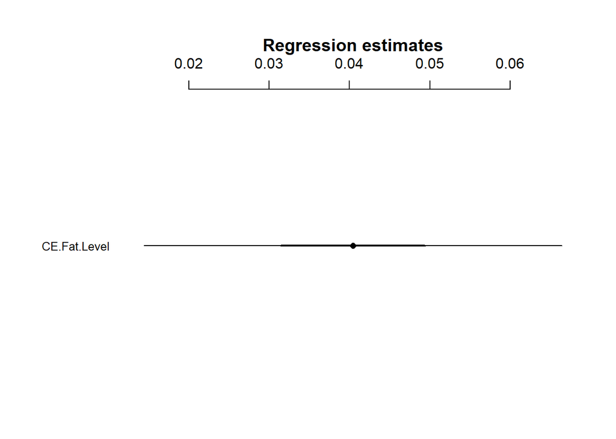

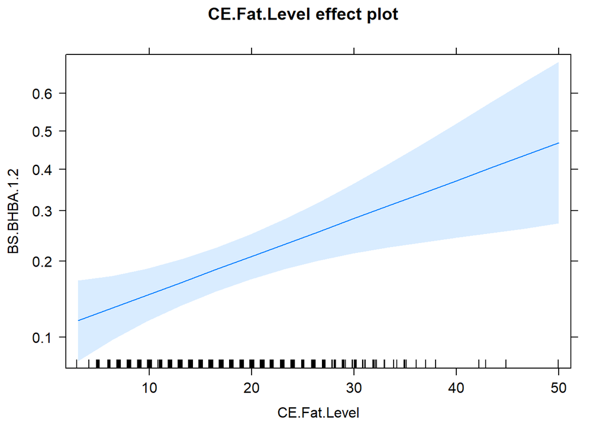

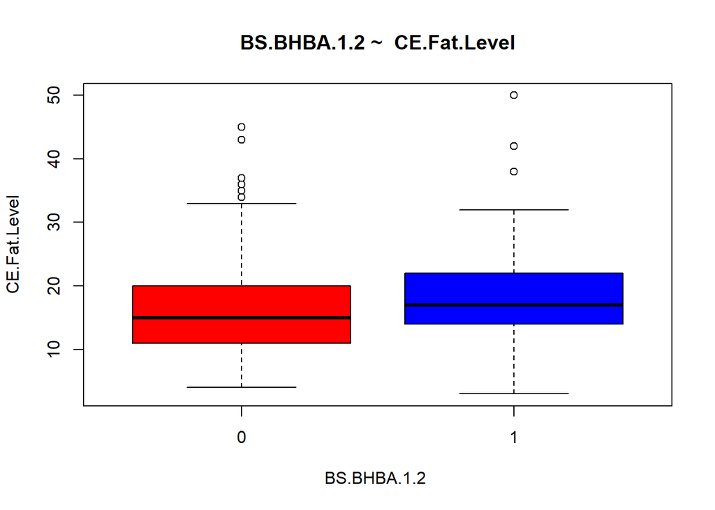

```r
##BHB3n creation - BS.BHBA.1.2 ~ BS.NEFA.Log

bhb3n <- glm(data = hp9, BS.BHBA.1.2 ~  BS.NEFA.Log , family = binomial(link = logit))

summary(bhb3n)
```

```
##
## Call:
## glm(formula = BS.BHBA.1.2 ~ BS.NEFA.Log, family = binomial(link = logit),
##     data = hp9)
##
## Deviance Residuals:
##     Min       1Q   Median       3Q      Max
## -1.1894  -0.7129  -0.5020  -0.3348   2.4998
##
## Coefficients:
##             Estimate Std. Error z value Pr(>|z|)
## (Intercept)  -0.5163     0.1459  -3.539 0.000402 ***
## BS.NEFA.Log   1.0149     0.1423   7.134 9.76e-13 ***
## ---
## Signif. codes:  0 '***' 0.001 '**' 0.01 '*' 0.05 '.' 0.1 ' ' 1
##
## (Dispersion parameter for binomial family taken to be 1)
##
##     Null deviance: 694.46  on 711  degrees of freedom
## Residual deviance: 634.16  on 710  degrees of freedom
## AIC: 638.16
##
## Number of Fisher Scoring iterations: 5
```

```r
#Calculating the 95% Confidence interval and the Odds Ratio
exp(cbind(OR = coef(bhb3n), confint(bhb3n)))
```

```
##                    OR     2.5 %    97.5 %
## (Intercept) 0.5967023 0.4472168 0.7930437
## BS.NEFA.Log 2.7590339 2.1021784 3.6747065
```

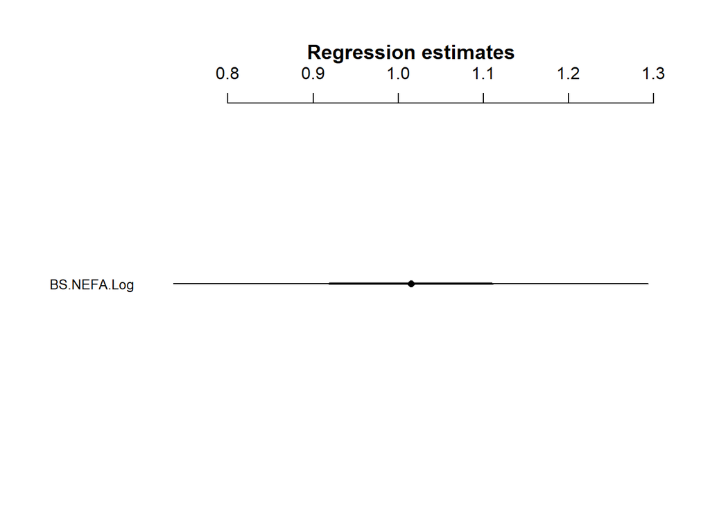

```r
coefplot2(bhb3n)
```

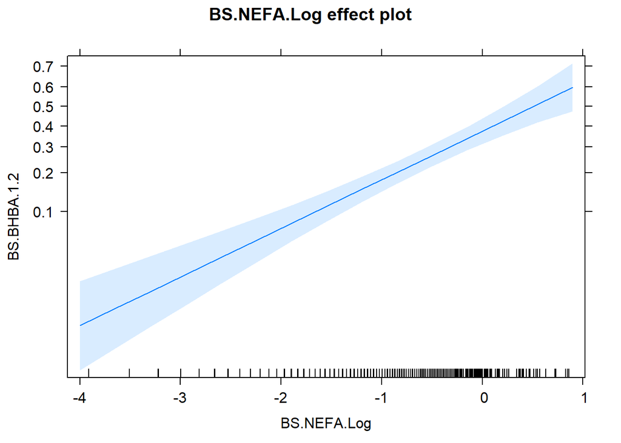

```r
plot(allEffects(bhb3n))
```